## ‘prev’ class structure and methods

Functions `truePrev`, `truePrevPools`, `truePrevMulti` and `truePrevMulti2` create objects of S4 class `prev`. Different methods are available for manipulating these objects.

### Slots

Objects of class `prev` are so-called `S4` objects. You can think of these objects as being formally defined lists. Instead of using the `$`-operator for accessing the different elements, which are called slots, the `@`-operator needs to be used. Objects of class `prev` contain the following four slots:

[output not shown]

### General methods

#### print method

```r
print(x, conf.level = 0.95, dig = 3, ...)
```

| `x` | An object of class `prev` |
| --- | --- |
| `conf.level` | Confidence level to be used in credibility interval |
| `dig` | Number of decimal digits to print |
| `...` | Other arguments to pass to the `print` function |

The `print` method prints the mean, median, mode, standard deviation and credibility interval of the estimated true prevalence (and sensitivities and specificities, for prev objects created by `truePrevMulti` and `truePrevMulti2`). In addition, the Brooks-Gelman-Rubin statistic and corresponding upper confidence limit are printed, or the multivariate BGR statistic for prev objects created by `truePrevMulti` and `truePrevMulti2`. BGR values substantially above 1 indicate lack of convergence. For `prev` objects created by `truePrevMulti`, the Bayes-P statistic is also printed. Bayes-P should be as close to 0.5 as possible.

#### summary method

```r
summary(object, conf.level)
```

| `object` | An object of class `prev` |
| --- | --- |
| `conf.level` | Confidence level to be used in credibility interval |

The `summary` method returns the mean, median, mode, standard deviation, variance, credibility interval and number of samples for each chain separately and for all chains combined.

#### as.matrix method

```r
as.matrix(x, iters = FALSE, chains = FALSE)
```

| `x` | An object of class `prev` |
| --- | --- |
| `iters` | Logical flag, indicating whether a column should be added for iteration number; defaults to `FALSE` |
| `chains` | Logical flag, indicating whether a column should be added for chain number; defaults to `FALSE` |

The `as.matrix` method converts objects of class `prev` to `matrix`.

#### plot method

```r
plot(x, y = NULL, ...)
```

| `x` | An object of class `prev` |
| --- | --- |
| `y` | Which parameter to plot? Defaults to `NULL` |
| `...` | Other arguments to pass to the `plot` function |

The `plot` method generates density, trace, Brooks-Gelman-Rubin and autocorrelation plots.

### Methods inherited from the [**coda**](https://cran.r-project.org/package=coda) package

#### densplot method

```r
densplot(x, exclude_fixed = TRUE, ...)
```

| `x` | An object of class `prev` |
| --- | --- |
| `exclude_fixed` | Should fixed parameters be excluded from plotting? Defaults to `TRUE` |
| `...` | Other arguments to pass to the `densplot` function |

Displays a plot of the density estimate for each variable in `x`, calculated by the `density` function.

#### traceplot method

```r
traceplot(x, exclude_fixed = TRUE, ...)
```

| `x` | An object of class `prev` |
| --- | --- |
| `exclude_fixed` | Should fixed parameters be excluded from plotting? Defaults to `TRUE` |
| `...` | Other arguments to pass to the `traceplot` function |

Displays a plot of iterations versus sampled values for each variable in the chain, with a separate plot per variable.

#### autocorr.plot method

```r
autocorr.plot(x, exclude_fixed = TRUE, chain = 1, ...)
```

| `x` | An object of class `prev` |
| --- | --- |
| `exclude_fixed` | Should fixed parameters be excluded from plotting? Defaults to `TRUE` |
| `chain` | Which chain to plot in `autocorr.plot`? Defaults to `1` |
| `...` | Other arguments to pass to the `autocorr.plot` function |

Plots the autocorrelation function for each variable in each chain in `x`.

### Examples

```r
## Taenia solium cysticercosis in Nepal
SE <- list(dist = "uniform", min = 0.60, max = 1.00)
SP <- list(dist = "uniform", min = 0.75, max = 1.00)
TP <- truePrev(x = 142, n = 742, SE = SE, SP = SP)
```

```r
## Summarize estimates per chain
summary(TP)
```

```
#> $TP
#>                 mean    median      mode         sd         var
#> chain 1    0.1371857 0.1371797 0.1899004 0.07788892 0.006066685
#> chain 2    0.1336157 0.1321198 0.1831823 0.07938643 0.006302206
#> all chains 0.1354007 0.1344100 0.1881068 0.07865953 0.006187322
#>                   2.5%     97.5% samples
#> chain 1    0.007131391 0.2847301   10000
#> chain 2    0.006826268 0.2867341   10000
#> all chains 0.006953099 0.2858581   20000
#>
#> $SE
#>                 mean    median      mode        sd        var      2.5%
#> chain 1    0.7781083 0.7664154 0.6305376 0.1160362 0.01346441 0.6066010
#> chain 2    0.7806555 0.7695690 0.6425182 0.1150805 0.01324352 0.6082347
#> all chains 0.7793819 0.7678970 0.6302666 0.1155635 0.01335492 0.6071912
#>                97.5% samples
#> chain 1    0.9867098   10000
#> chain 2    0.9874131   10000
#> all chains 0.9870292   20000
#>
#> $SP
#>                 mean    median      mode         sd         var      2.5%
#> chain 1    0.9009873 0.9005704 0.8490157 0.05666717 0.003211168 0.8045467
#> chain 2    0.8990168 0.8968261 0.8380739 0.05781682 0.003342784 0.8032723
#> all chains 0.9000021 0.8986753 0.8478642 0.05725192 0.003277783 0.8039108
#>                97.5% samples
#> chain 1    0.9938295   10000
#> chain 2    0.9939376   10000
#> all chains 0.9938842   20000
```

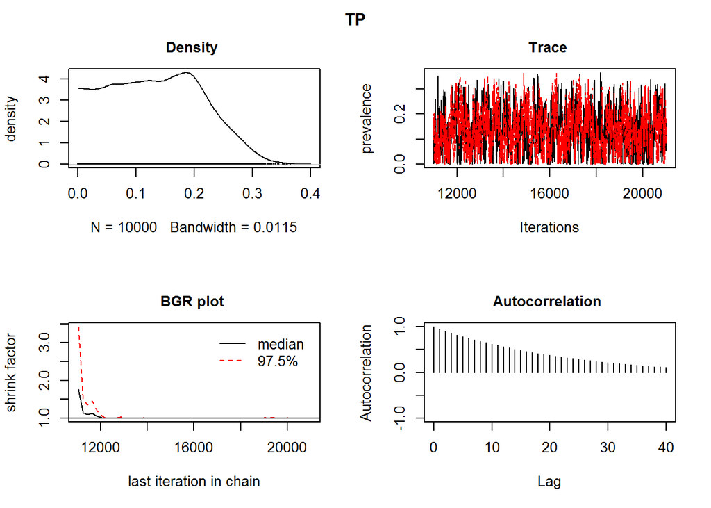

```r
## Diagnostic plots
par(mfrow = c(2, 2))
plot(TP)
```

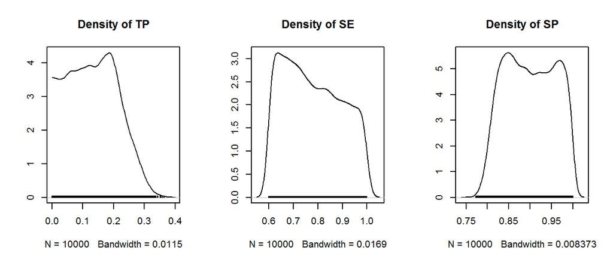

```r
## Generic plots from package coda
par(mfrow = c(1, 3))
densplot(TP)
```

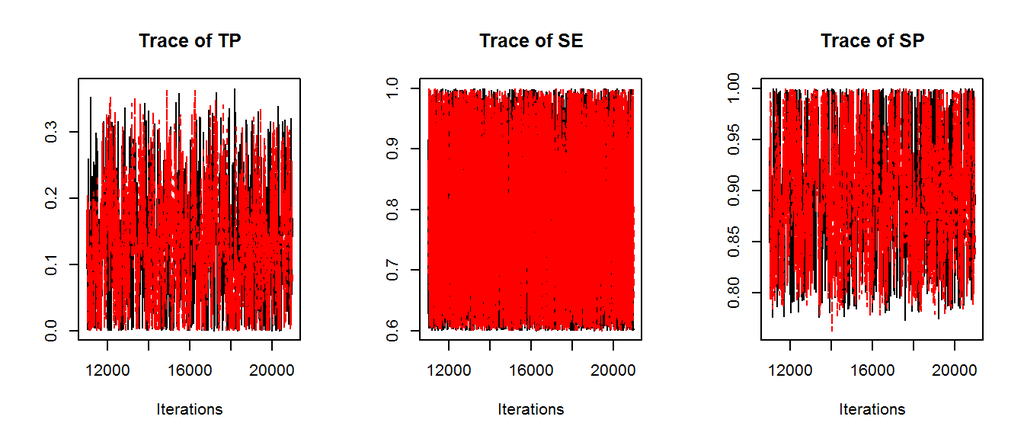

```r
par(mfrow = c(1, 3))
traceplot(TP)
```

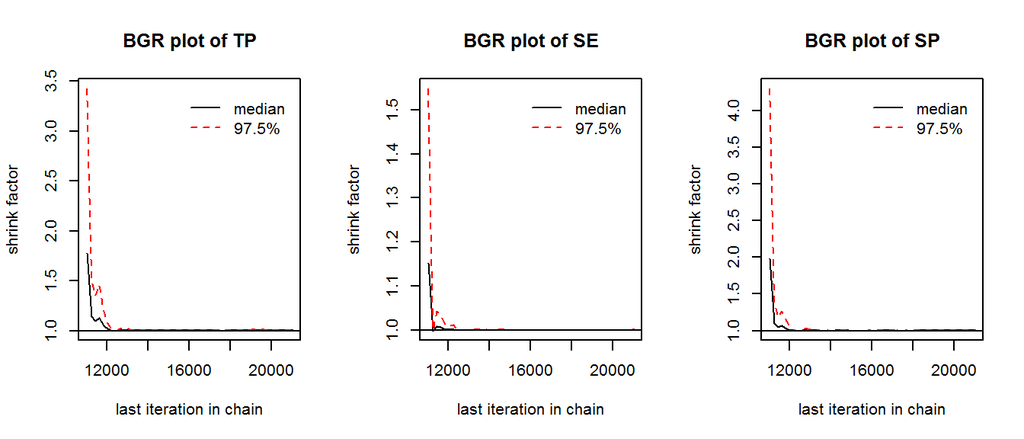

```r
par(mfrow = c(1, 3))
gelman.plot(TP)
```

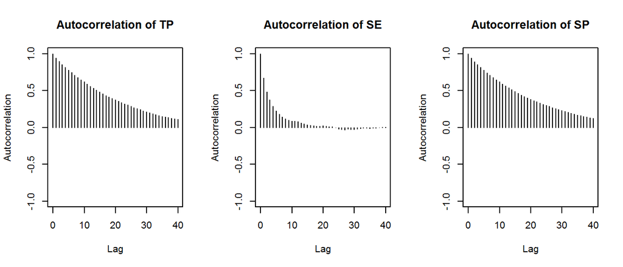

```r
par(mfrow = c(1, 3))
autocorr.plot(TP)
```

```r
## Use 'str()' to see the structure of object TP
str(TP)
```

```
#> Formal class 'prev' [package "prevalence"] with 4 slots
#>   ..@ par        :List of 9
#>   .. ..$ x      : num 142
#>   .. ..$ n      : num 742
#>   .. ..$ SE     :List of 2
#>   .. .. ..$ d: chr "uniform"
#>   .. .. ..$ p: num [1:2] 0.6 1
#>   .. ..$ SP     :List of 2
#>   .. .. ..$ d: chr "uniform"
#>   .. .. ..$ p: num [1:2] 0.75 1
#>   .. ..$ prior  : num [1:2] 1 1
#>   .. ..$ nchains: num 2
#>   .. ..$ burnin : num 10000
#>   .. ..$ update : num 10000
#>   .. ..$ inits  : NULL
#>   ..@ model      :Class 'prevModel'  chr [1:7] "model {" "x ~ dbin(AP, n)" "AP <- SE * TP + (1 - SP) * (1 - TP)" "SE ~ dunif(0.6, 1)" ...
#>   ..@ mcmc       :List of 3
#>   .. ..$ TP:List of 2
#>   .. .. ..$ :Class 'mcmc'  atomic [1:10000] 0.125 0.1236 0.1076 0.0944 0.133 ...
#>   .. .. .. .. ..- attr(*, "mcpar")= num [1:3] 11001 21000 1
#>   .. .. ..$ :Class 'mcmc'  atomic [1:10000] 0.111 0.0971 0.1033 0.1291 0.1516 ...
#>   .. .. .. .. ..- attr(*, "mcpar")= num [1:3] 11001 21000 1
#>   .. .. ..- attr(*, "class")= chr "mcmc.list"
#>   .. ..$ SE:List of 2
#>   .. .. ..$ :Class 'mcmc'  atomic [1:10000] 0.673 0.696 0.788 0.693 0.629 ...
#>   .. .. .. .. ..- attr(*, "mcpar")= num [1:3] 11001 21000 1
#>   .. .. ..$ :Class 'mcmc'  atomic [1:10000] 0.825 0.834 0.88 0.806 0.835 ...
#>   .. .. .. .. ..- attr(*, "mcpar")= num [1:3] 11001 21000 1
#>   .. .. ..- attr(*, "class")= chr "mcmc.list"
#>   .. ..$ SP:List of 2
#>   .. .. ..$ :Class 'mcmc'  atomic [1:10000] 0.877 0.87 0.868 0.863 0.861 ...
#>   .. .. .. .. ..- attr(*, "mcpar")= num [1:3] 11001 21000 1
#>   .. .. ..$ :Class 'mcmc'  atomic [1:10000] 0.884 0.875 0.917 0.89 0.927 ...
#>   .. .. .. .. ..- attr(*, "mcpar")= num [1:3] 11001 21000 1
#>   .. .. ..- attr(*, "class")= chr "mcmc.list"
#>   ..@ diagnostics:List of 2
#>   .. ..$ DIC:List of 3
#>   .. .. ..$ deviance:Class 'mcarray'  Named num 7.58
#>   .. .. .. .. ..- attr(*, "names")= chr "x"
#>   .. .. ..$ penalty :Class 'mcarray'  Named num 0.968
#>   .. .. .. .. ..- attr(*, "names")= chr "x"
#>   .. .. ..$ type    : chr "pD"
#>   .. .. ..- attr(*, "class")= chr "dic"
#>   .. ..$ BGR:List of 2
#>   .. .. ..$ psrf : num [1:3, 1:2] 1 1 1 1 1 ...
#>   .. .. .. ..- attr(*, "dimnames")=List of 2
#>   .. .. .. .. ..$ : chr [1:3] "SE" "SP" "TP"
#>   .. .. .. .. ..$ : chr [1:2] "Point est." "Upper C.I."
#>   .. .. ..$ mpsrf: num 1
#>   .. .. ..- attr(*, "class")= chr "gelman.diag"
```

```r
## Every slot can be accessed using the '@' operator
slotNames(TP)
```

```
#> [1] "par"         "model"       "mcmc"        "diagnostics"
```

```r
## .. input parameters
TP@par
```

```
#> $x
#> [1] 142
#>
#> $n
#> [1] 742
#>
#> $SE
#> $SE$d
#> [1] "uniform"
#>
#> $SE$p
#> [1] 0.6 1.0
#>
#>
#> $SP
#> $SP$d
#> [1] "uniform"
#>
#> $SP$p
#> [1] 0.75 1.00
#>
#>
#> $prior
#> [1] 1 1
#>
#> $nchains
#> [1] 2
#>
#> $burnin
#> [1] 10000
#>
#> $update
#> [1] 10000
#>
#> $inits
#> NULL
```

```r
## .. fitted model
TP@model
```

```
#> model {
#>   x ~ dbin(AP, n)
#>   AP <- SE * TP + (1 - SP) * (1 - TP)
#>   SE ~ dunif(0.6, 1)
#>   SP ~ dunif(0.75, 1)
#>   TP ~ dbeta(1, 1)
#> }
```

```r
## .. simulated TP, SE, SP
str(TP@mcmc)
```

```
#> List of 3
#>  $ TP:List of 2
#>   ..$ :Class 'mcmc'  atomic [1:10000] 0.125 0.1236 0.1076 0.0944 0.133 ...
#>   .. .. ..- attr(*, "mcpar")= num [1:3] 11001 21000 1
#>   ..$ :Class 'mcmc'  atomic [1:10000] 0.111 0.0971 0.1033 0.1291 0.1516 ...
#>   .. .. ..- attr(*, "mcpar")= num [1:3] 11001 21000 1
#>   ..- attr(*, "class")= chr "mcmc.list"
#>  $ SE:List of 2
#>   ..$ :Class 'mcmc'  atomic [1:10000] 0.673 0.696 0.788 0.693 0.629 ...
#>   .. .. ..- attr(*, "mcpar")= num [1:3] 11001 21000 1
#>   ..$ :Class 'mcmc'  atomic [1:10000] 0.825 0.834 0.88 0.806 0.835 ...
#>   .. .. ..- attr(*, "mcpar")= num [1:3] 11001 21000 1
#>   ..- attr(*, "class")= chr "mcmc.list"
#>  $ SP:List of 2
#>   ..$ :Class 'mcmc'  atomic [1:10000] 0.877 0.87 0.868 0.863 0.861 ...
#>   .. .. ..- attr(*, "mcpar")= num [1:3] 11001 21000 1
#>   ..$ :Class 'mcmc'  atomic [1:10000] 0.884 0.875 0.917 0.89 0.927 ...
#>   .. .. ..- attr(*, "mcpar")= num [1:3] 11001 21000 1
#>   ..- attr(*, "class")= chr "mcmc.list"
```

```r
## .. convert simulated TP, SE, SP to matrix
head(as.matrix(TP))
```

```
#>              TP        SE        SP
#> [1,] 0.12497886 0.6729475 0.8774353
#> [2,] 0.12357302 0.6959699 0.8699901
#> [3,] 0.10761131 0.7880032 0.8683324
#> [4,] 0.09438967 0.6927515 0.8632794
#> [5,] 0.13304616 0.6286654 0.8607214
#> [6,] 0.12531370 0.7360327 0.8846877
```

```r
## .. DIC and BGR (and bayesP)
TP@diagnostics
```

```
#> $DIC
#> Mean deviance:  7.576
#> penalty 0.9684
#> Penalized deviance: 8.544
#>
#> $BGR
#> Potential scale reduction factors:
#>
#>    Point est. Upper C.I.
#> SE          1          1
#> SP          1          1
#> TP          1          1
#>
#> Multivariate psrf
#>
#> 1
```

```r
## TP@mcmc elements inherit from class 'mcmc.list' in coda package
## List all available methods for this class
methods(class = "mcmc.list")
```

```
#>  [1] [             acfplot       as.array      as.matrix     as.mcmc
#>  [6] autocorr.diag batchSE       coerce        densityplot   end
#> [11] head          HPDinterval   initialize    plot          qqmath
#> [16] rejectionRate show          slotsFromS3   start         summary
#> [21] tail          thin          time          window        xyplot
#> see '?methods' for accessing help and source code
```

Page last modified: Mon, 08 Feb 2016. [View Rmarkdown source code on GitHub](https://github.com/brechtdv/prevalence-www).